# Predicting Recidivism in Boward County, FL

[figure not shown]

```r
#pruning tree based on min cp
cp.index <- which.min(tree.full$cptable[, "xerror"])
cp.use <- tree.full$cptable[, "CP"][cp.index]

tree.pruned <- prune(tree.full, cp = cp.use)
plot(tree.pruned)
text(tree.pruned, pretty=0)
```

[figure not shown]

```r
tree.pruned.party <- as.party(tree.pruned)
plot(tree.pruned.party)
```

```r
#fitting and predicting on pruned tree
tree.pruned.predict <- predict(tree.pruned, newdata = raw.score.df.test, type = "prob")

t.conf <- confusionMatrix(data = as.factor(ifelse(tree.pruned.predict[, "1"] > 0.5, 1, 0)),
                reference = as.factor(raw.score.df.test$is_recid),
                dnn = c("Prediction", "Reference"))
t.conf
```

```
## Confusion Matrix and Statistics
##
##           Reference
## Prediction    0    1
##          0   81   68
##          1  653 3641
##
##                Accuracy : 0.8377
##                  95% CI : (0.8265, 0.8485)
##     No Information Rate : 0.8348
##     P-Value [Acc > NIR] : 0.308
##
##                   Kappa : 0.1353
##
##  Mcnemar's Test P-Value : <2e-16
##
##             Sensitivity : 0.11035
##             Specificity : 0.98167
##          Pos Pred Value : 0.54362
##          Neg Pred Value : 0.84793
##              Prevalence : 0.16520
##          Detection Rate : 0.01823
##    Detection Prevalence : 0.03354
##       Balanced Accuracy : 0.54601
##
##        'Positive' Class : 0
##
```

This classifier performs pretty well, at 83.77%, but we had to make the CP very low to get it to work, and large trees such as this one are very high variance trees, so it may not be the best model for this data.

**3.16 Random Forest**

Because one tree by itself has low bias but high variance, we turn to a random forest classifier to see if it would predict a little bit better.

```r
#random forest
rf.fit <- randomForest(is_recid ~ ., data = raw.score.df.train)
print(rf.fit)
```

```
##
## Call:
##  randomForest(formula = is_recid ~ ., data = raw.score.df.train)
##                Type of random forest: classification
##                      Number of trees: 500
## No. of variables tried at each split: 3
##
##         OOB estimate of  error rate: 16.32%
## Confusion matrix:
##     0     1 class.error
## 0 158  2851 0.947490861
## 1  50 14712 0.003387075
```

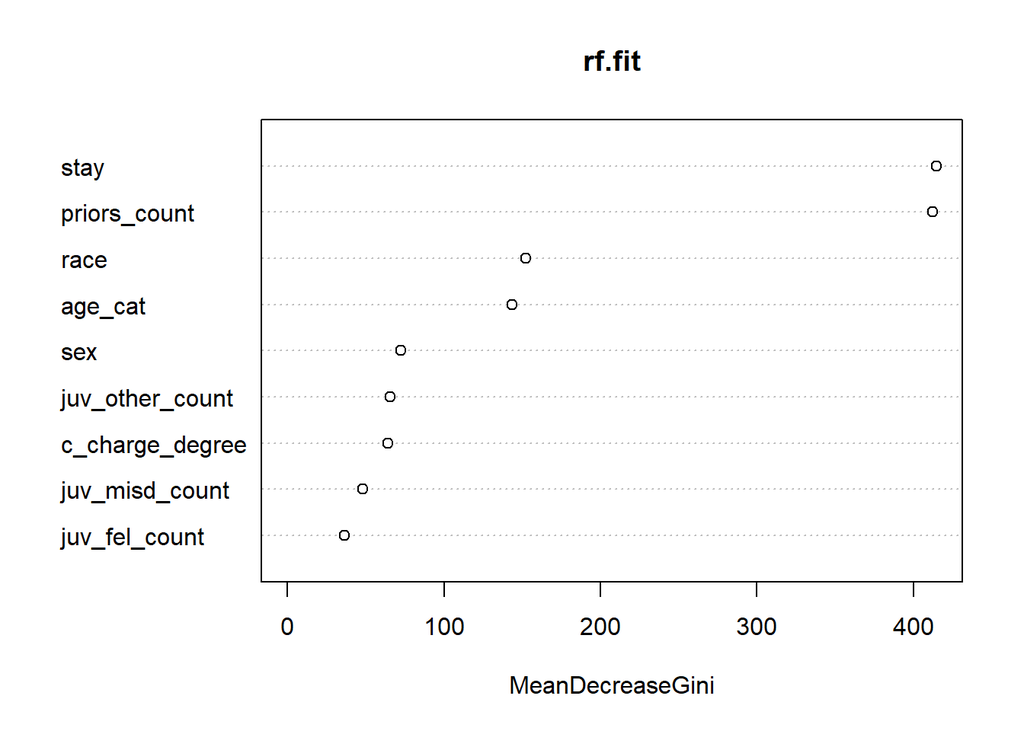

```r
varImpPlot(rf.fit)
```

```r
rf.predict <- predict(rf.fit, newdata = raw.score.df.test, type = "prob")
rf.conf <- confusionMatrix(data = as.factor(ifelse(rf.predict[, "1"] > 0.5, 1, 0)),
                reference = as.factor(raw.score.df.test$is_recid),
                dnn = c("Prediction", "Reference"))
rf.conf
```

```
## Confusion Matrix and Statistics
##
##           Reference
## Prediction    0    1
##          0   39    9
##          1  695 3700
##
##                Accuracy : 0.8415
##                  95% CI : (0.8305, 0.8522)
##     No Information Rate : 0.8348
##     P-Value [Acc > NIR] : 0.1163
##
##                   Kappa : 0.0811
##
##  Mcnemar's Test P-Value : <2e-16
##
##             Sensitivity : 0.053134
##             Specificity : 0.997573
##          Pos Pred Value : 0.812500
##          Neg Pred Value : 0.841866
##              Prevalence : 0.165204
##          Detection Rate : 0.008778
##    Detection Prevalence : 0.010804
##       Balanced Accuracy : 0.525353
##
##        'Positive' Class : 0
##
```

We see that with this one, the most important variables seem to be `stay`, and `priors_count`, with `race` and `age_cat` as our seecond tier important variables.

The random forest performs with a classification rate of about 84.15%, which is also pretty high.

**Conclusion** : Random forest has the highest classification rate here (just a little bit more than the logistic regression), so we picked that as our winning model. Interpretibility issues aresomething to be taken into account here, so logistic regression is an alternative option that has about the same classification score and a higher level of interpretibility.

**3.2 Violent Recidivism**

**3.21 Logistic Regression**

## Model Formation

```r
general.violent.fit <- glm(is_violent_recid ~ ., family = "binomial", data = raw.score.violent.df)
# summary(general.violent.fit)
##which factors show statistical significance
general.violent.summary <- coef(summary(general.violent.fit))[,'Pr(>|z|)']
names(general.violent.summary[general.violent.summary<= .05])
```

```
##  [1] "(Intercept)"            "sexMale"
##  [3] "age_cat25 - 45"         "age_catGreater than 45"
##  [5] "raceCaucasian"          "raceHispanic"
##  [7] "juv_fel_count"          "juv_misd_count"
##  [9] "juv_other_count"        "priors_count"
## [11] "stay"
```

Gender, Age Category, Race, juv felony count, juv misdemeanor count, juv other count, priors count, and stay are all statstically significant

## Evaulate most important variables

```r
set.seed(150)
subset.violent.data <- raw.score.violent.df[sample(nrow(raw.score.violent.df), 3607), ]
raw.data.violent.subset <- regsubsets(is_violent_recid ~ .,
                              data = subset.violent.data,
                              nbest = 1,
                              nvmax = NULL,
                              method = "forward", really.big = TRUE)
```

BIC test was chosen since we have only very few predictors

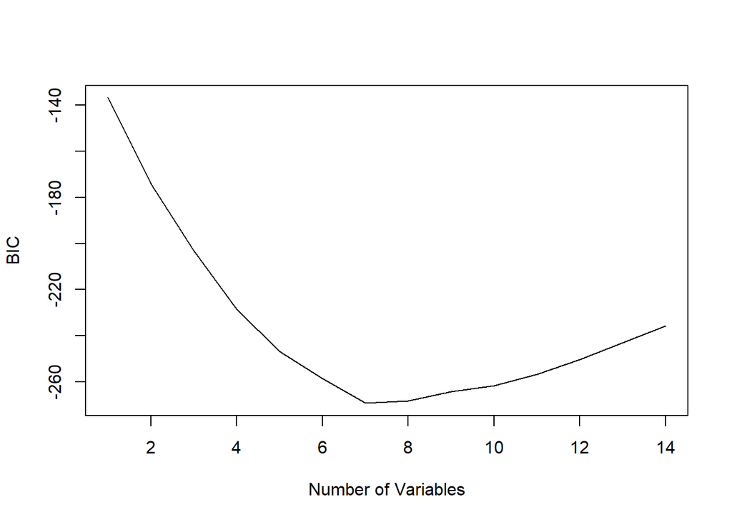

```r
# Running BIC test
BIC.violent.summary <- summary(raw.data.violent.subset)
plot(BIC.violent.summary$bic, xlab  = "Number of Variables", ylab = "BIC", type = "l")
```

```r
print(names(coef(raw.data.violent.subset, id = which.min(BIC.violent.summary$bic))))
```

```
## [1] "(Intercept)"            "sexMale"
## [3] "age_cat25 - 45"         "age_catGreater than 45"
## [5] "juv_misd_count"         "juv_other_count"
## [7] "priors_count"           "stay"
```

## Prediction with Logistic Regression

```r
#logistic regression
log.violent.fit <- glm(is_violent_recid ~ ., family = "binomial", data = raw.score.violent.df.train)
glm.violent.predict <- predict(log.violent.fit, newdata = raw.score.violent.df.test, type = "response")

glm.conf.v <- confusionMatrix(data = as.factor(ifelse(glm.violent.predict > 0.6, 1, 0)),
                reference = as.factor(raw.score.violent.df.test$is_violent_recid),
                dnn = c("Prediction", "Reference"))

glm.conf.v
```

```
## Confusion Matrix and Statistics
##
##           Reference
## Prediction    0    1
##          0   91   93
##          1  708 3057
##
##                Accuracy : 0.7972
##                  95% CI : (0.7843, 0.8096)
##     No Information Rate : 0.7977
##     P-Value [Acc > NIR] : 0.541
##
##                   Kappa : 0.1184
##
##  Mcnemar's Test P-Value : <2e-16
##
##             Sensitivity : 0.11389
##             Specificity : 0.97048
##          Pos Pred Value : 0.49457
##          Neg Pred Value : 0.81195
##              Prevalence : 0.20233
##          Detection Rate : 0.02304
##    Detection Prevalence : 0.04659
##       Balanced Accuracy : 0.54218
##
##        'Positive' Class : 0
##
```

This model has a classification rate of 79.72%, which is slightly lower than the generalized recidivism model. it is worth noting that more cases are being categorized as 1 (meaning the person is likely going to commit a crime again) regardless of whether they have done so.

### ROC CURVE FOR LOGISTIC REGRESSION

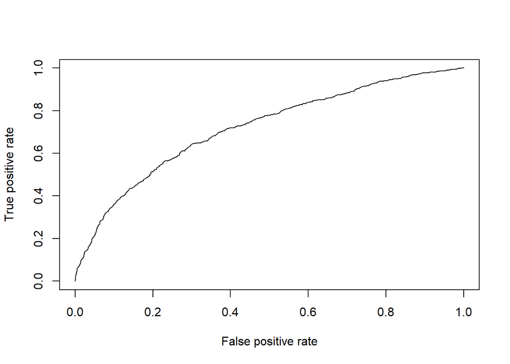

```r
violent.predicts <- predict(log.violent.fit, type = 'response')
ROCRpred.violent <- prediction(violent.predicts, raw.score.violent.df.train$is_violent_recid)
ROCRperf.violent <- performance(ROCRpred.violent, 'tpr', 'fpr')
plot(ROCRperf.violent)
```

The ROC curve (like before) shows that this current model also cannot achieve very high true positive rate and a low false positive rate. However, compared to the general ROC curve found earlier, this curve is shifted more to the upright in comparison to the previous one. This means that our classification is doing some level of good compared to just randomly choosing the classifications.

**3.22 LDA**

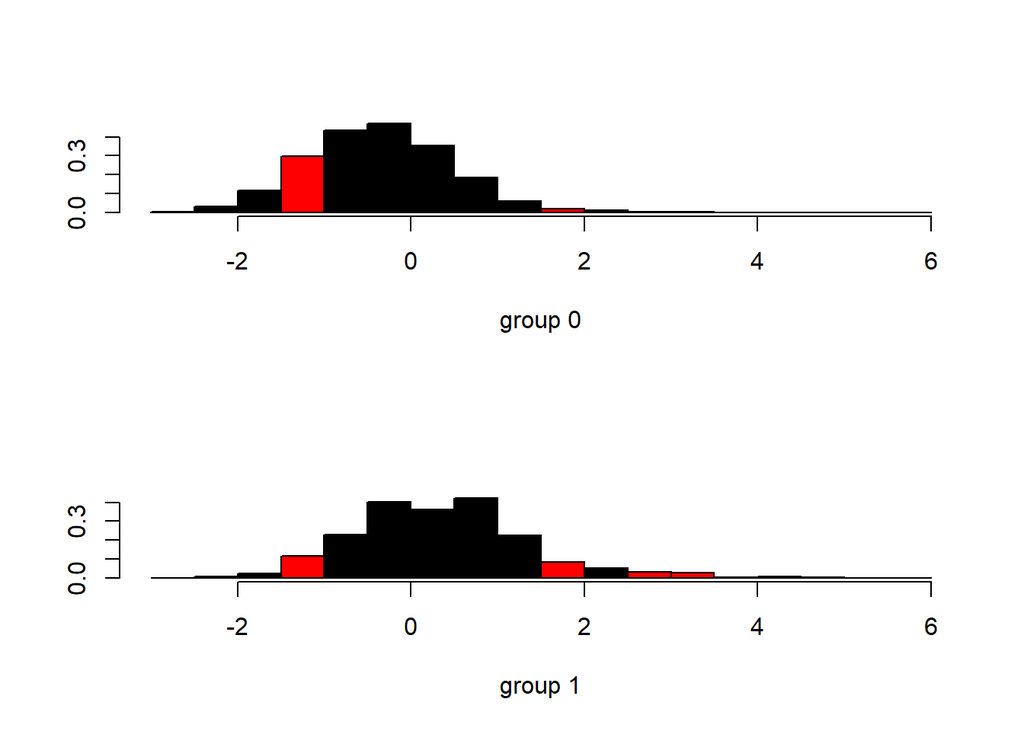

```r
lda.violent.fit <- lda(is_violent_recid ~ ., data = raw.score.violent.df.train)

plot(lda.violent.fit, col = as.numeric(raw.score.violent.df.train$is_violent_recid))
```

```r
lda.violent.predict <- predict(lda.violent.fit, newdata = raw.score.violent.df.test)
lda.conf.v <- confusionMatrix(data = as.factor(lda.violent.predict$class),
                reference = as.factor(raw.score.violent.df.test$is_violent_recid),
                dnn = c("Prediction", "Reference"))
lda.conf.v
```

```
## Confusion Matrix and Statistics
##
##           Reference
## Prediction    0    1
##          0   17   16
##          1  782 3134
##
##                Accuracy : 0.7979
##                  95% CI : (0.7851, 0.8104)
##     No Information Rate : 0.7977
##     P-Value [Acc > NIR] : 0.4937
##
##                   Kappa : 0.0252
##
##  Mcnemar's Test P-Value : <2e-16
##
##             Sensitivity : 0.021277
##             Specificity : 0.994921
##          Pos Pred Value : 0.515152
##          Neg Pred Value : 0.800306
##              Prevalence : 0.202330
##          Detection Rate : 0.004305
##    Detection Prevalence : 0.008357
##       Balanced Accuracy : 0.508099
##
##        'Positive' Class : 0
##
```

The classification rate is 79.79%. This achieves a similar classification rate to the logisitic regression.

**3.23 QDA**

```r
qda.violent.fit <- qda(is_violent_recid ~ ., data = raw.score.violent.df.train)

qda.violent.predict <- predict(qda.violent.fit, newdata = raw.score.violent.df.test)
qda.conf.v <- confusionMatrix(data = as.factor(qda.violent.predict$class),
                reference = as.factor(raw.score.violent.df.test$is_violent_recid),
                dnn = c("Prediction", "Reference"))
qda.conf.v
```

```
## Confusion Matrix and Statistics
##
##           Reference
## Prediction    0    1
##          0  700 2079
##          1   99 1071
##
##                Accuracy : 0.4485
##                  95% CI : (0.4329, 0.4641)
##     No Information Rate : 0.7977
##     P-Value [Acc > NIR] : 1
##
##                   Kappa : 0.1123
##
##  Mcnemar's Test P-Value : <2e-16
##
##             Sensitivity : 0.8761
##             Specificity : 0.3400
##          Pos Pred Value : 0.2519
##          Neg Pred Value : 0.9154
##              Prevalence : 0.2023
##          Detection Rate : 0.1773
##    Detection Prevalence : 0.7037
##       Balanced Accuracy : 0.6080
##
##        'Positive' Class : 0
##
```

This achieved a low classification rate of 44.85%.

**3.33 Naive Bayes**

```r
nb.violent.fit <- NaiveBayes(is_violent_recid ~ ., data = raw.score.violent.df.train)

nb.violent.predict <- predict(nb.violent.fit, newdata = raw.score.violent.df.test)
nb.conf.v <- confusionMatrix(data = as.factor(nb.violent.predict$class),
                reference = as.factor(raw.score.violent.df.test$is_violent_recid),
                dnn = c("Prediction", "Reference"))
nb.conf.v
```

```
## Confusion Matrix and Statistics
##
##           Reference
## Prediction    0    1
##          0  696 2158
##          1  103  992
##
##                Accuracy : 0.4274
##                  95% CI : (0.412, 0.4431)
##     No Information Rate : 0.7977
##     P-Value [Acc > NIR] : 1
##
##                   Kappa : 0.0949
##
##  Mcnemar's Test P-Value : <2e-16
##
##             Sensitivity : 0.8711
##             Specificity : 0.3149
##          Pos Pred Value : 0.2439
##          Neg Pred Value : 0.9059
##              Prevalence : 0.2023
##          Detection Rate : 0.1762
##    Detection Prevalence : 0.7227
##       Balanced Accuracy : 0.5930
##
##        'Positive' Class : 0
##
```

The classification rate is 42.74%, which is much lower compared to the other models, which again makes sense since most of our variables are likely correlated.

**3.34 Tree**

We then turn again to trees, building a very large one and then pruning it back based on CP.

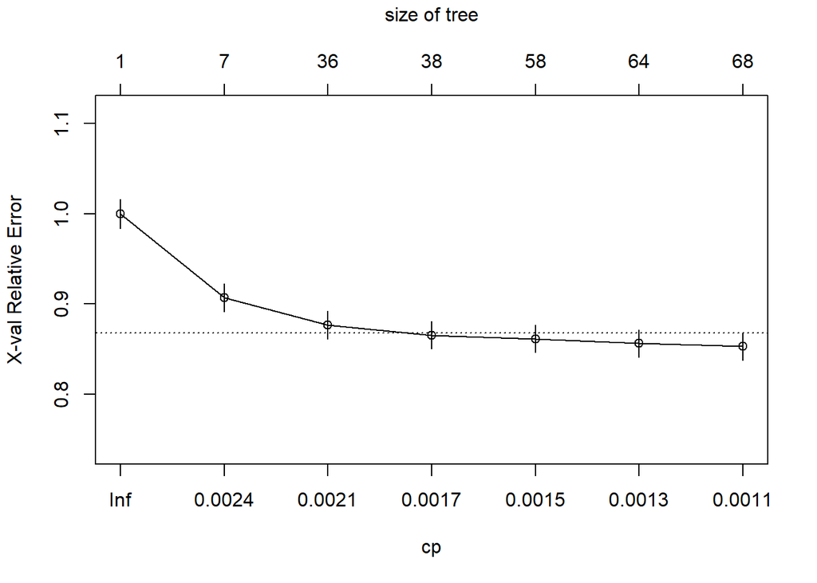

```r
#making a full tree, violent
tree.violent.full <- rpart(is_violent_recid ~ ., data = raw.score.violent.df.train,
                       control = rpart.control(minsplit=50, cp=0.001))
plotcp(tree.violent.full)
```

```r
tree.violent.full$cptable
```

```
##        CP nsplit rel error  xerror       xstd
## 1 0.00248      0   1.00000 1.00000 0.01602139
## 2 0.00232      6   0.98496 0.90688 0.01543144
## 3 0.00192     35   0.86080 0.87680 0.01522829
## 4 0.00152     37   0.85696 0.86560 0.01515098
## 5 0.00144     57   0.81536 0.86144 0.01512203
## 6 0.00120     63   0.80672 0.85632 0.01508623
## 7 0.00100     67   0.80192 0.85312 0.01506376
```

[figure not shown]

```r
tree.violent.full.party <- as.party(tree.violent.full)
plot(tree.violent.full.party)
```

```r
print(tree.violent.full.party)
```

```
##
## Model formula:
## is_violent_recid ~ sex + age_cat + race + juv_fel_count + juv_misd_count +
##     juv_other_count + priors_count + c_charge_degree + stay
##
## Fitted party:
## [1] root
## |   [2] priors_count < 2.5
## |   |   [3] stay < 2.5
## |   |   |   [4] race in Asian, Caucasian, Hispanic, Native American, Other
## |   |   |   |   [5] priors_count < 1.5
## |   |   |   |   |   [6] race in Asian, Hispanic, Native American, Other
## |   |   |   |   |   |   [7] stay >= 1.5: 0 (n = 39, err = 0.0%)
## |   |   |   |   |   |   [8] stay < 1.5
## |   |   |   |   |   |   |   [9] sex in Female
## |   |   |   |   |   |   |   |   [10] age_cat in Less than 25, Greater than 45: 0 (n = 41, err = 0.0%)
## |   |   |   |   |   |   |   |   [11] age_cat in 25 - 45
## |   |   |   |   |   |   |   |   |   [12] race in Other: 0 (n = 18, err = 0.0%)
## |   |   |   |   |   |   |   |   |   [13] race in Hispanic: 1 (n = 53, err = 35.8%)
## |   |   |   |   |   |   |   [14] sex in Male
## |   |   |   |   |   |   |   |   [15] age_cat in 25 - 45, Greater than 45
## |   |   |   |   |   |   |   |   |   [16] race in Asian, Hispanic, Native American
## |   |   |   |   |   |   |   |   |   |   [17] stay >= 0.5: 0 (n = 71, err = 0.0%)
## |   |   |   |   |   |   |   |   |   |   [18] stay < 0.5: 1 (n = 101, err = 33.7%)
## |   |   |   |   |   |   |   |   |   [19] race in Other
## |   |   |   |   |   |   |   |   |   |   [20] priors_count < 0.5
## |   |   |   |   |   |   |   |   |   |   |   [21] age_cat in 25 - 45: 0 (n = 38, err = 34.2%)
## |   |   |   |   |   |   |   |   |   |   |   [22] age_cat in Greater than 45: 1 (n = 49, err = 34.7%)
## |   |   |   |   |   |   |   |   |   |   [23] priors_count >= 0.5: 1 (n = 57, err = 26.3%)
## |   |   |   |   |   |   |   |   [24] age_cat in Less than 25: 1 (n = 152, err = 29.6%)
## |   |   |   |   |   [25] race in Caucasian
## |   |   |   |   |   |   [26] age_cat in Less than 25, Greater than 45
## |   |   |   |   |   |   |   [27] stay < 0.5
## |   |   |   |   |   |   |   |   [28] age_cat in Less than 25: 0 (n = 39, err = 0.0%)
## |   |   |   |   |   |   |   |   [29] age_cat in Greater than 45
## |   |   |   |   |   |   |   |   |   [30] priors_count >= 0.5: 0 (n = 17, err = 0.0%)
## |   |   |   |   |   |   |   |   |   [31] priors_count < 0.5: 1 (n = 85, err = 35.3%)
## |   |   |   |   |   |   |   [32] stay >= 0.5
## |   |   |   |   |   |   |   |   [33] priors_count < 0.5
## |   |   |   |   |   |   |   |   |   [34] age_cat in Greater than 45: 0 (n = 137, err = 29.2%)
```

[output cut: 89 more lines]

```
## |   |   |   [124] age_cat in Less than 25: 1 (n = 1152, err = 11.6%)
## |   [125] priors_count >= 2.5
## |   |   [126] stay < 0.5
## |   |   |   [127] priors_count < 3.5
## |   |   |   |   [128] race in Caucasian, Hispanic, Other: 0 (n = 31, err = 0.0%)
## |   |   |   |   [129] race in African-American: 1 (n = 70, err = 30.0%)
## |   |   |   [130] priors_count >= 3.5
## |   |   |   |   [131] age_cat in Greater than 45
## |   |   |   |   |   [132] juv_other_count < 0.5: 0 (n = 64, err = 37.5%)
## |   |   |   |   |   [133] juv_other_count >= 0.5: 1 (n = 30, err = 6.7%)
## |   |   |   |   [134] age_cat in Less than 25, 25 - 45: 1 (n = 479, err = 12.7%)
## |   |   [135] stay >= 0.5: 1 (n = 7018, err = 9.6%)
##
## Number of inner nodes:    67
## Number of terminal nodes: 68
```

```r
#pruning tree based on min cp
cp.index <- which.min(tree.violent.full$cptable[, "xerror"])
cp.use <- tree.violent.full$cptable[, "CP"][cp.index]
cp.use
```

```
##     7
## 0.001
```

[figure not shown]

```r
tree.violent.pruned <- prune(tree.violent.full, cp = cp.use)
plot(tree.violent.pruned)
text(tree.violent.pruned, pretty=0)
```

[figure not shown]

```r
tree.violent.pruned.party <- as.party(tree.violent.pruned)
plot(tree.violent.pruned.party)
```

```r
print(tree.violent.pruned.party)
```

```
##
## Model formula:
## is_violent_recid ~ sex + age_cat + race + juv_fel_count + juv_misd_count +
##     juv_other_count + priors_count + c_charge_degree + stay
##
## Fitted party:
## [1] root
## |   [2] priors_count < 2.5
## |   |   [3] stay < 2.5
## |   |   |   [4] race in Asian, Caucasian, Hispanic, Native American, Other
## |   |   |   |   [5] priors_count < 1.5
## |   |   |   |   |   [6] race in Asian, Hispanic, Native American, Other
## |   |   |   |   |   |   [7] stay >= 1.5: 0 (n = 39, err = 0.0%)
## |   |   |   |   |   |   [8] stay < 1.5
## |   |   |   |   |   |   |   [9] sex in Female
## |   |   |   |   |   |   |   |   [10] age_cat in Less than 25, Greater than 45: 0 (n = 41, err = 0.0%)
## |   |   |   |   |   |   |   |   [11] age_cat in 25 - 45
## |   |   |   |   |   |   |   |   |   [12] race in Other: 0 (n = 18, err = 0.0%)
## |   |   |   |   |   |   |   |   |   [13] race in Hispanic: 1 (n = 53, err = 35.8%)
## |   |   |   |   |   |   |   [14] sex in Male
## |   |   |   |   |   |   |   |   [15] age_cat in 25 - 45, Greater than 45
## |   |   |   |   |   |   |   |   |   [16] race in Asian, Hispanic, Native American
## |   |   |   |   |   |   |   |   |   |   [17] stay >= 0.5: 0 (n = 71, err = 0.0%)
## |   |   |   |   |   |   |   |   |   |   [18] stay < 0.5: 1 (n = 101, err = 33.7%)
## |   |   |   |   |   |   |   |   |   [19] race in Other
## |   |   |   |   |   |   |   |   |   |   [20] priors_count < 0.5
## |   |   |   |   |   |   |   |   |   |   |   [21] age_cat in 25 - 45: 0 (n = 38, err = 34.2%)
## |   |   |   |   |   |   |   |   |   |   |   [22] age_cat in Greater than 45: 1 (n = 49, err = 34.7%)
## |   |   |   |   |   |   |   |   |   |   [23] priors_count >= 0.5: 1 (n = 57, err = 26.3%)
## |   |   |   |   |   |   |   |   [24] age_cat in Less than 25: 1 (n = 152, err = 29.6%)
## |   |   |   |   |   [25] race in Caucasian
## |   |   |   |   |   |   [26] age_cat in Less than 25, Greater than 45
## |   |   |   |   |   |   |   [27] stay < 0.5
## |   |   |   |   |   |   |   |   [28] age_cat in Less than 25: 0 (n = 39, err = 0.0%)
## |   |   |   |   |   |   |   |   [29] age_cat in Greater than 45
## |   |   |   |   |   |   |   |   |   [30] priors_count >= 0.5: 0 (n = 17, err = 0.0%)
## |   |   |   |   |   |   |   |   |   [31] priors_count < 0.5: 1 (n = 85, err = 35.3%)
## |   |   |   |   |   |   |   [32] stay >= 0.5
## |   |   |   |   |   |   |   |   [33] priors_count < 0.5
## |   |   |   |   |   |   |   |   |   [34] age_cat in Greater than 45: 0 (n = 137, err = 29.2%)
```

[output cut: 89 more lines]

```
## |   |   |   [124] age_cat in Less than 25: 1 (n = 1152, err = 11.6%)
## |   [125] priors_count >= 2.5
## |   |   [126] stay < 0.5
## |   |   |   [127] priors_count < 3.5
## |   |   |   |   [128] race in Caucasian, Hispanic, Other: 0 (n = 31, err = 0.0%)
## |   |   |   |   [129] race in African-American: 1 (n = 70, err = 30.0%)
## |   |   |   [130] priors_count >= 3.5
## |   |   |   |   [131] age_cat in Greater than 45
## |   |   |   |   |   [132] juv_other_count < 0.5: 0 (n = 64, err = 37.5%)
## |   |   |   |   |   [133] juv_other_count >= 0.5: 1 (n = 30, err = 6.7%)
## |   |   |   |   [134] age_cat in Less than 25, 25 - 45: 1 (n = 479, err = 12.7%)
## |   |   [135] stay >= 0.5: 1 (n = 7018, err = 9.6%)
##
## Number of inner nodes:    67
## Number of terminal nodes: 68
```

```r
#fitting and predicting on pruned tree
tree.violent.pruned.predict <- predict(tree.violent.pruned, newdata = raw.score.violent.df.test, type = "prob")

t.conf.v <- confusionMatrix(data = as.factor(ifelse(tree.violent.pruned.predict[, "1"] > 0.5, 1, 0)),
                reference = as.factor(raw.score.violent.df.test$is_violent_recid),
                dnn = c("Prediction", "Reference"))
t.conf.v
```

```
## Confusion Matrix and Statistics
##
##           Reference
## Prediction    0    1
##          0  204   59
##          1  595 3091
##
##                Accuracy : 0.8344
##                  95% CI : (0.8224, 0.8459)
##     No Information Rate : 0.7977
##     P-Value [Acc > NIR] : 2.303e-09
##
##                   Kappa : 0.3156
##
##  Mcnemar's Test P-Value : < 2.2e-16
##
##             Sensitivity : 0.25532
##             Specificity : 0.98127
##          Pos Pred Value : 0.77567
##          Neg Pred Value : 0.83858
##              Prevalence : 0.20233
##          Detection Rate : 0.05166
##    Detection Prevalence : 0.06660
##       Balanced Accuracy : 0.61829
##
##        'Positive' Class : 0
##
```

The tree performs with a rate of 83.44%, and again we look at random forests as well.

## RANDOM FOREST

Again, because we want to account for the high variance on our single tree, we also fit our data to a random forest model.

```r
#violent
rf.violent.fit <- randomForest(is_violent_recid ~ ., data = raw.score.violent.df.train)
print(rf.violent.fit)
```

```
##
## Call:
##  randomForest(formula = is_violent_recid ~ ., data = raw.score.violent.df.train)
##                Type of random forest: classification
##                      Number of trees: 500
## No. of variables tried at each split: 3
##
##         OOB estimate of  error rate: 15.35%
## Confusion matrix:
##     0     1 class.error
## 0 740  2385  0.76320000
## 1  39 12630  0.00307838
```

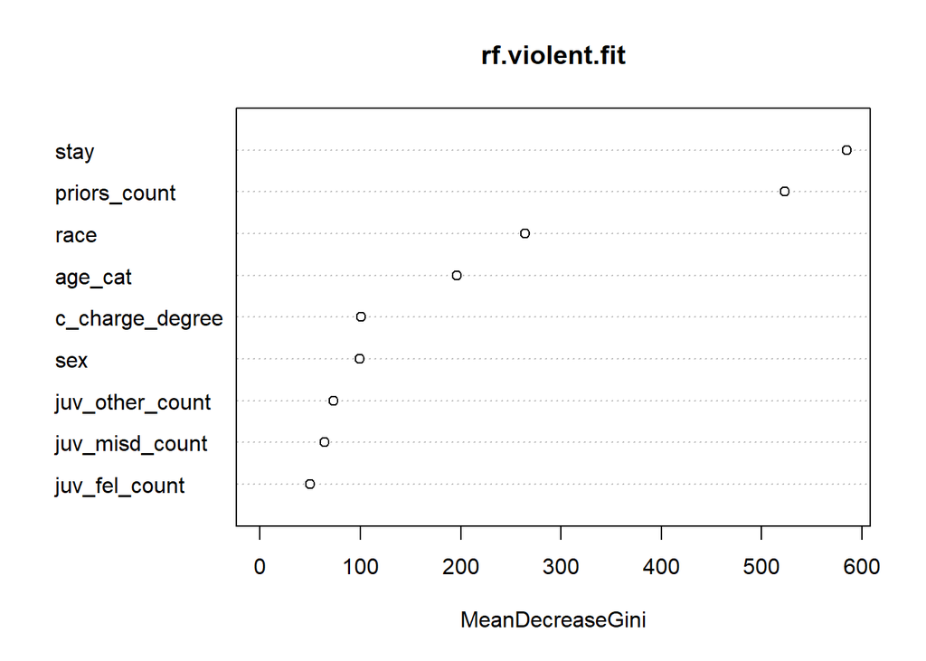

```r
varImpPlot(rf.violent.fit)
```

```r
rf.violent.predict <- predict(rf.violent.fit, newdata = raw.score.violent.df.test, type = "prob")
rf.conf.v <- confusionMatrix(data = as.factor(ifelse(rf.violent.predict[, "1"] > 0.5, 1, 0)),
                reference = as.factor(raw.score.violent.df.test$is_violent_recid),
                dnn = c("Prediction", "Reference"))
rf.conf.v
```

```
## Confusion Matrix and Statistics
##
##           Reference
## Prediction    0    1
##          0  180    9
##          1  619 3141
##
##                Accuracy : 0.841
##                  95% CI : (0.8292, 0.8522)
##     No Information Rate : 0.7977
##     P-Value [Acc > NIR] : 1.832e-12
##
##                   Kappa : 0.311
##
##  Mcnemar's Test P-Value : < 2.2e-16
##
##             Sensitivity : 0.22528
##             Specificity : 0.99714
##          Pos Pred Value : 0.95238
##          Neg Pred Value : 0.83537
##              Prevalence : 0.20233
##          Detection Rate : 0.04558
##    Detection Prevalence : 0.04786
##       Balanced Accuracy : 0.61121
##
##        'Positive' Class : 0
##
```

Here, we see that `stay` and `priors_count` are the two most important variables, with `race` and `age_cat` again being the second tier most important. This achieves a classification rate of 84.1%.

**4. Comparing our two RAIs to each other**

Our next step is to see if the two RAI’s that are constructured are equally predictive across race/ethnicity, age, and gender.

**4.1 Race**

### Data cleaning

First we filter out our datasets to each level of the `race` variable so we can check for systemic differences between them. Through our EDA, we know that African-American and Caucasian are the two largest races we have in this data, so we focus on them for this analysis.

```r
#nonviolent

raw.score.df.black.train <- filter(raw.score.df.train, race == "African-American")
raw.score.df.white.train <- filter(raw.score.df.train, race == "Caucasian")

raw.score.df.black.test <- filter(raw.score.df.test, race == "African-American")
raw.score.df.white.test <- filter(raw.score.df.test, race == "Caucasian")

#violent

raw.score.violent.df.black.train <- filter(raw.score.violent.df.train, race == "African-American")
raw.score.violent.df.white.train <- filter(raw.score.violent.df.train, race == "Caucasian")

raw.score.violent.df.black.test <- filter(raw.score.violent.df.test, race == "African-American")
raw.score.violent.df.white.test <- filter(raw.score.violent.df.test, race == "Caucasian")
```

Next, we’ll test our winning models on these categories.

### Random Forest for Nonviolent

```r
#random forest
rf.black.fit <- randomForest(is_recid ~ ., data = raw.score.df.black.train)
print(rf.black.fit)
```

```
##
## Call:
##  randomForest(formula = is_recid ~ ., data = raw.score.df.black.train)
##                Type of random forest: classification
##                      Number of trees: 500
## No. of variables tried at each split: 3
##
##         OOB estimate of  error rate: 13.33%
## Confusion matrix:
##   0    1  class.error
## 0 9 1322 0.9932381668
## 1 1 8596 0.0001163196
```

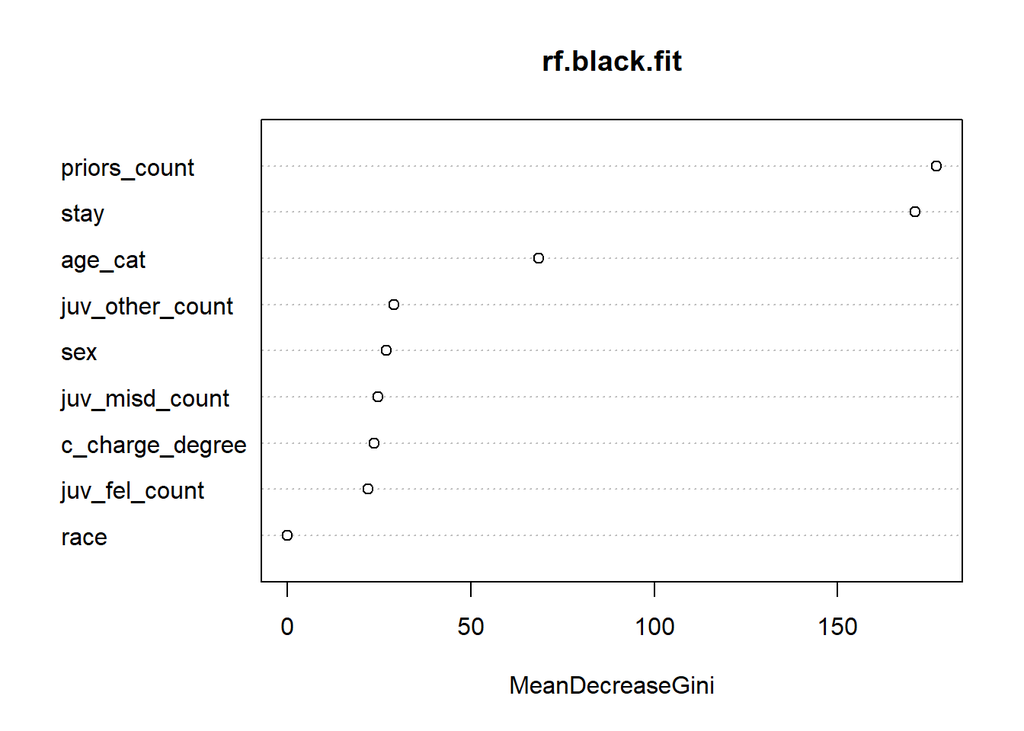

```r
varImpPlot(rf.black.fit)
```

```r
rf.black.predict <- predict(rf.black.fit, newdata = raw.score.df.black.test, type = "prob")
conf.black <- confusionMatrix(data = as.factor(ifelse(rf.black.predict[, "1"] > 0.5, 1, 0)),
                reference = as.factor(raw.score.df.black.test$is_recid),
                dnn = c("Prediction", "Reference"))
conf.black
```

```
## Confusion Matrix and Statistics
##
##           Reference
## Prediction    0    1
##          0    0    0
##          1  329 2167
##
##                Accuracy : 0.8682
##                  95% CI : (0.8543, 0.8812)
##     No Information Rate : 0.8682
##     P-Value [Acc > NIR] : 0.5147
##
##                   Kappa : 0
##
##  Mcnemar's Test P-Value : <2e-16
##
##             Sensitivity : 0.0000
##             Specificity : 1.0000
##          Pos Pred Value :    NaN
##          Neg Pred Value : 0.8682
##              Prevalence : 0.1318
##          Detection Rate : 0.0000
##    Detection Prevalence : 0.0000
##       Balanced Accuracy : 0.5000
##
##        'Positive' Class : 0
##
```

For African Americans, the classification rate is about 86.82%, with largely the same variables being important (with race falling to the bottom for obvious reasons).

```r
#random forest
rf.white.fit <- randomForest(is_recid ~ ., data = raw.score.df.white.train)
print(rf.white.fit)
```

```
##
## Call:
##  randomForest(formula = is_recid ~ ., data = raw.score.df.white.train)
##                Type of random forest: classification
##                      Number of trees: 500
## No. of variables tried at each split: 3
##
##         OOB estimate of  error rate: 20.54%
## Confusion matrix:
##    0    1 class.error
## 0 40 1112 0.965277778
## 1 39 4412 0.008762076
```

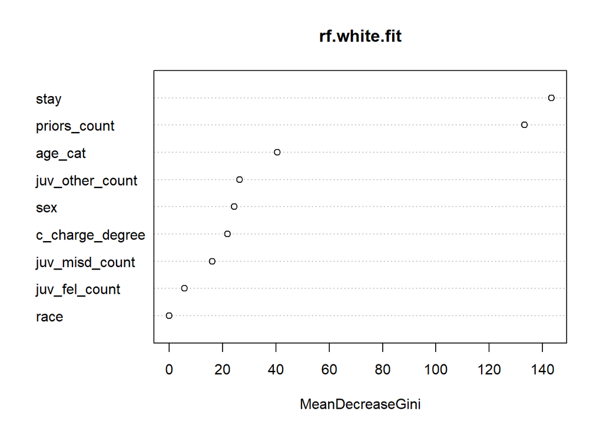

```r
varImpPlot(rf.white.fit)
```

```r
rf.white.predict <- predict(rf.white.fit, newdata = raw.score.df.white.test, type = "prob")
conf.white <- confusionMatrix(data = as.factor(ifelse(rf.white.predict[, "1"] > 0.5, 1, 0)),
                reference = as.factor(raw.score.df.white.test$is_recid),
                dnn = c("Prediction", "Reference"))
conf.white
```

```
## Confusion Matrix and Statistics
##
##           Reference
## Prediction    0    1
##          0   18    5
##          1  259 1106
##
##                Accuracy : 0.8098
##                  95% CI : (0.7881, 0.8301)
##     No Information Rate : 0.8004
##     P-Value [Acc > NIR] : 0.2012
##
##                   Kappa : 0.0922
##
##  Mcnemar's Test P-Value : <2e-16
##
##             Sensitivity : 0.06498
##             Specificity : 0.99550
##          Pos Pred Value : 0.78261
##          Neg Pred Value : 0.81026
##              Prevalence : 0.19957
##          Detection Rate : 0.01297
##    Detection Prevalence : 0.01657
##       Balanced Accuracy : 0.53024
##
##        'Positive' Class : 0
##
```

Our classification rate for white folks is about 80.98%, which compared to the accuracy of African Americans, implies some sort of racial bias within either the system or our model.

### Random Forest for Violent

```r
#violent
rf.violent.black.fit <- randomForest(is_violent_recid ~ ., data = raw.score.violent.df.black.train)
print(rf.violent.black.fit)
```

```
##
## Call:
##  randomForest(formula = is_violent_recid ~ ., data = raw.score.violent.df.black.train)
##                Type of random forest: classification
##                      Number of trees: 500
## No. of variables tried at each split: 3
##
##         OOB estimate of  error rate: 14.13%
## Confusion matrix:
##     0    1 class.error
## 0 112 1282   0.9196557
## 1   0 7677   0.0000000
```

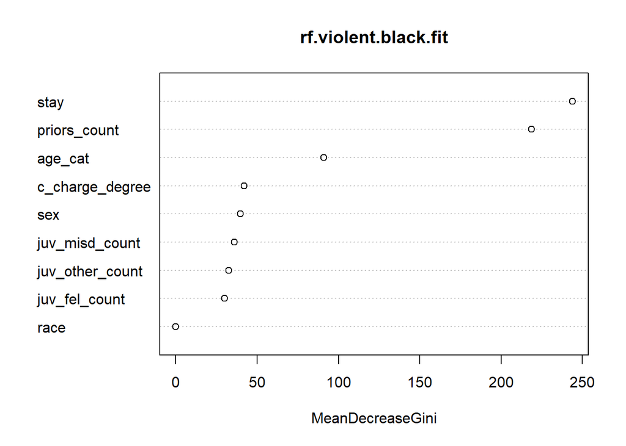

```r
varImpPlot(rf.violent.black.fit)
```

```r
rf.violent.black.predict <- predict(rf.violent.black.fit, newdata = raw.score.violent.df.black.test, type = "prob")
conf.black.v <- confusionMatrix(data = as.factor(ifelse(rf.violent.black.predict[, "1"] > 0.5, 1, 0)),
                reference = as.factor(raw.score.violent.df.black.test$is_violent_recid),
                dnn = c("Prediction", "Reference"))
conf.black.v
```

```
## Confusion Matrix and Statistics
##
##           Reference
## Prediction    0    1
##          0   30    0
##          1  347 1897
##
##                Accuracy : 0.8474
##                  95% CI : (0.832, 0.862)
##     No Information Rate : 0.8342
##     P-Value [Acc > NIR] : 0.04696
##
##                   Kappa : 0.1261
##
##  Mcnemar's Test P-Value : < 2e-16
##
##             Sensitivity : 0.07958
##             Specificity : 1.00000
##          Pos Pred Value : 1.00000
##          Neg Pred Value : 0.84537
##              Prevalence : 0.16579
##          Detection Rate : 0.01319
##    Detection Prevalence : 0.01319
##       Balanced Accuracy : 0.53979
##
##        'Positive' Class : 0
##
```

Our accuracy rate here is about 84.74% with again about the same important variables.

```r
#violent
rf.violent.white.fit <- randomForest(is_violent_recid ~ ., data = raw.score.violent.df.white.train)
print(rf.violent.white.fit)
```

```
##
## Call:
##  randomForest(formula = is_violent_recid ~ ., data = raw.score.violent.df.white.train)
##                Type of random forest: classification
##                      Number of trees: 500
## No. of variables tried at each split: 3
##
##         OOB estimate of  error rate: 20.42%
## Confusion matrix:
##     0    1 class.error
## 0 250  920  0.78632479
## 1  26 3436  0.00751011
```

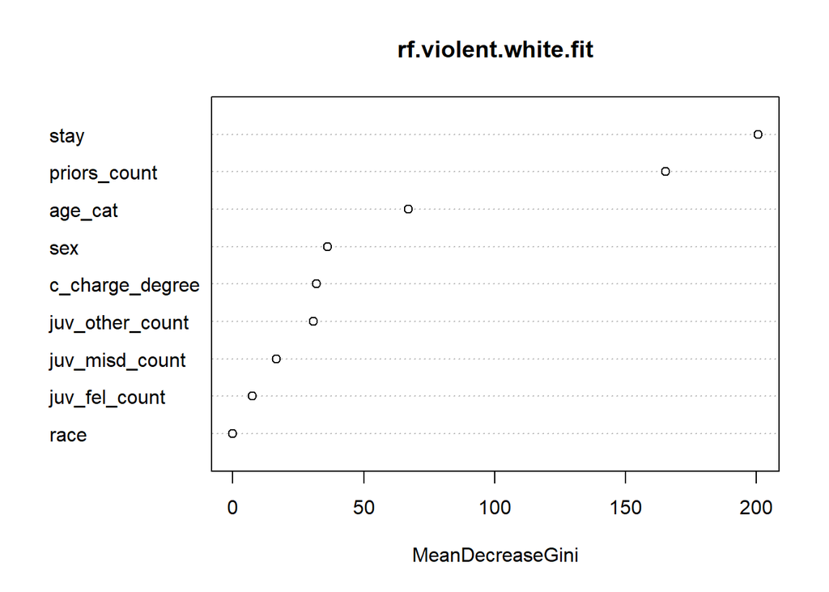

```r
varImpPlot(rf.violent.white.fit)
```

```r
rf.violent.white.predict <- predict(rf.violent.white.fit, newdata = raw.score.violent.df.white.test, type = "prob")
conf.white.v <- confusionMatrix(data = as.factor(ifelse(rf.violent.white.predict[, "1"] > 0.5, 1, 0)),
                reference = as.factor(raw.score.violent.df.white.test$is_violent_recid),
                dnn = c("Prediction", "Reference"))
conf.white.v
```

```
## Confusion Matrix and Statistics
##
##           Reference
## Prediction   0   1
##          0  70   6
##          1 239 851
##
##                Accuracy : 0.7899
##                  95% CI : (0.7654, 0.8129)
##     No Information Rate : 0.735
##     P-Value [Acc > NIR] : 8.093e-06
##
##                   Kappa : 0.2893
##
##  Mcnemar's Test P-Value : < 2.2e-16
##
##             Sensitivity : 0.22654
##             Specificity : 0.99300
##          Pos Pred Value : 0.92105
##          Neg Pred Value : 0.78073
##              Prevalence : 0.26501
##          Detection Rate : 0.06003
##    Detection Prevalence : 0.06518
##       Balanced Accuracy : 0.60977
##
##        'Positive' Class : 0
##
```

Our accuracy again falls to about 78.99%, which again implies some sort of racial bias in this problem.

**4.2 Gender**

### Data Cleaning

Again, first we filter out.

```r
#nonviolent
raw.score.df.fem.train <- filter(raw.score.df.train, sex == "Female")
raw.score.df.male.train <- filter(raw.score.df.train, sex == "Male")

raw.score.df.fem.test <- filter(raw.score.df.test, sex == "Female")
raw.score.df.male.test <- filter(raw.score.df.test, sex == "Male")

#violent
raw.score.violent.df.fem.train <- filter(raw.score.violent.df.train, sex == "Female")
raw.score.violent.df.male.train <- filter(raw.score.violent.df.train, sex == "Male")

raw.score.violent.df.fem.test <- filter(raw.score.violent.df.test, sex == "Female")
raw.score.violent.df.male.test <- filter(raw.score.violent.df.test, sex == "Male")
```

### Random Forest for Nonviolent

```r
#random forest
rf.fem.fit <- randomForest(is_recid ~ ., data = raw.score.df.fem.train)
print(rf.fem.fit)
```

```
##
## Call:
##  randomForest(formula = is_recid ~ ., data = raw.score.df.fem.train)
##                Type of random forest: classification
##                      Number of trees: 500
## No. of variables tried at each split: 3
##
##         OOB estimate of  error rate: 20.89%
## Confusion matrix:
##     0    1 class.error
## 0 127  568  0.81726619
## 1  54 2228  0.02366345
```

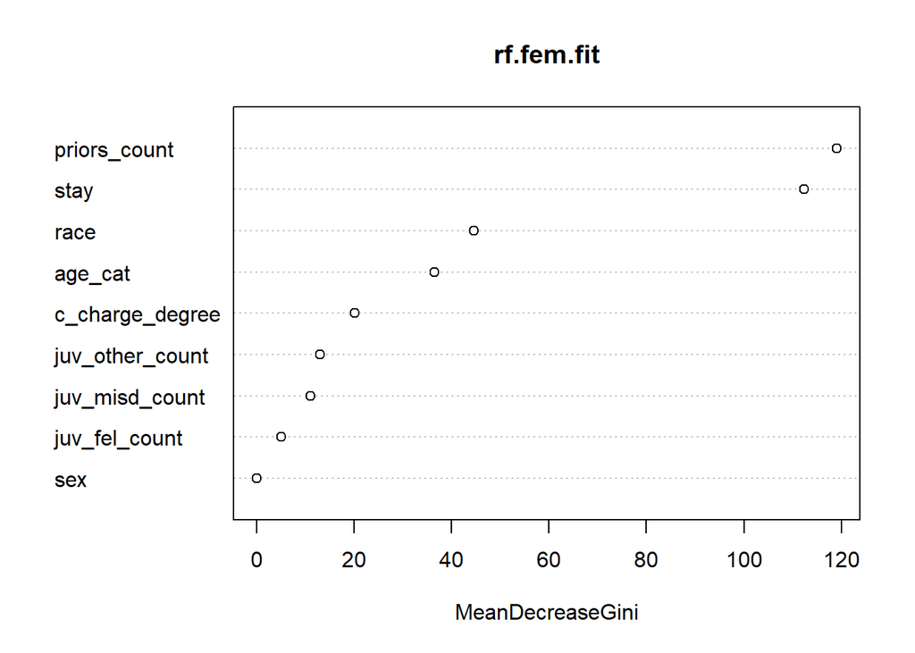

```r
varImpPlot(rf.fem.fit)
```

```r
rf.fem.predict <- predict(rf.fem.fit, newdata = raw.score.df.fem.test, type = "prob")
conf.fem <- confusionMatrix(data = as.factor(ifelse(rf.fem.predict[, "1"] > 0.5, 1, 0)),
                reference = as.factor(raw.score.df.fem.test$is_recid),
                dnn = c("Prediction", "Reference"))
conf.fem
```

```
## Confusion Matrix and Statistics
##
##           Reference
## Prediction   0   1
##          0  30  10
##          1 140 603
##
##                Accuracy : 0.8084
##                  95% CI : (0.7791, 0.8354)
##     No Information Rate : 0.7829
##     P-Value [Acc > NIR] : 0.04395
##
##                   Kappa : 0.2213
##
##  Mcnemar's Test P-Value : < 2e-16
##
##             Sensitivity : 0.17647
##             Specificity : 0.98369
##          Pos Pred Value : 0.75000
##          Neg Pred Value : 0.81157
##              Prevalence : 0.21711
##          Detection Rate : 0.03831
##    Detection Prevalence : 0.05109
##       Balanced Accuracy : 0.58008
##
##        'Positive' Class : 0
##
```

We achieve an 80.84% classification rate for women in this dataset, with the important variables this time including `race` and `age_cat`.

```r
#random forest
rf.male.fit <- randomForest(is_recid ~ ., data = raw.score.df.male.train)
print(rf.male.fit)
```

```
##
## Call:
##  randomForest(formula = is_recid ~ ., data = raw.score.df.male.train)
##                Type of random forest: classification
##                      Number of trees: 500
## No. of variables tried at each split: 3
##
##         OOB estimate of  error rate: 15.43%
## Confusion matrix:
##    0     1  class.error
## 0 34  2280 0.9853068280
## 1  3 12477 0.0002403846
```

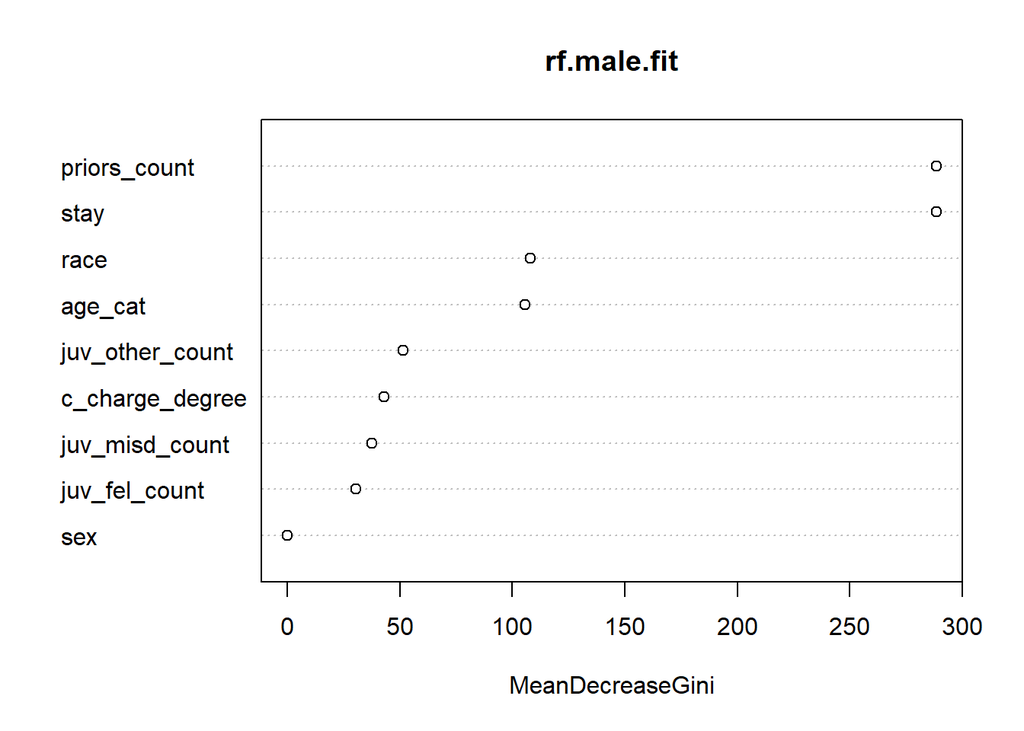

```r
varImpPlot(rf.male.fit)
```

```r
rf.male.predict <- predict(rf.male.fit, newdata = raw.score.df.male.test, type = "prob")
conf.male <- confusionMatrix(data = as.factor(ifelse(rf.male.predict[, "1"] > 0.5, 1, 0)),
                reference = as.factor(raw.score.df.male.test$is_recid),
                dnn = c("Prediction", "Reference"))
conf.male
```

```
## Confusion Matrix and Statistics
##
##           Reference
## Prediction    0    1
##          0    6    0
##          1  558 3096
##
##                Accuracy : 0.8475
##                  95% CI : (0.8355, 0.859)
##     No Information Rate : 0.8459
##     P-Value [Acc > NIR] : 0.4025
##
##                   Kappa : 0.0179
##
##  Mcnemar's Test P-Value : <2e-16
##
##             Sensitivity : 0.010638
##             Specificity : 1.000000
##          Pos Pred Value : 1.000000
##          Neg Pred Value : 0.847291
##              Prevalence : 0.154098
##          Detection Rate : 0.001639
##    Detection Prevalence : 0.001639
##       Balanced Accuracy : 0.505319
##
##        'Positive' Class : 0
##
```

Our classification rate here is 84.75%, which implies a gender bias in our model as well.

### Random Forest for Violent

```r
#violent
rf.violent.fem.fit <- randomForest(is_violent_recid ~ ., data = raw.score.violent.df.fem.train)
print(rf.violent.fem.fit)
```

```
##
## Call:
##  randomForest(formula = is_violent_recid ~ ., data = raw.score.violent.df.fem.train)
##                Type of random forest: classification
##                      Number of trees: 500
## No. of variables tried at each split: 3
##
##         OOB estimate of  error rate: 17.98%
## Confusion matrix:
##     0    1 class.error
## 0 313  398  0.55977496
## 1  26 1621  0.01578628
```

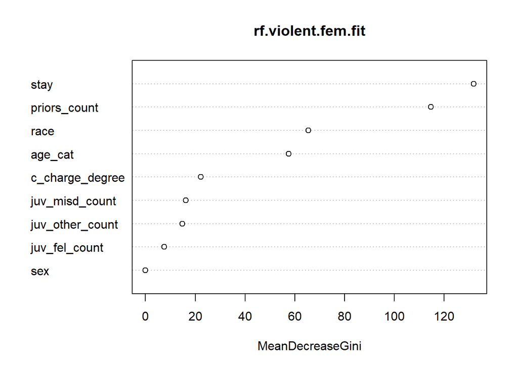

```r
varImpPlot(rf.violent.fem.fit)
```

```r
rf.violent.fem.predict <- predict(rf.violent.fem.fit, newdata = raw.score.violent.df.fem.test, type = "prob")
conf.fem.v <- confusionMatrix(data = as.factor(ifelse(rf.violent.fem.predict[, "1"] > 0.5, 1, 0)),
                reference = as.factor(raw.score.violent.df.fem.test$is_violent_recid),
                dnn = c("Prediction", "Reference"))
conf.fem.v
```

```
## Confusion Matrix and Statistics
##
##           Reference
## Prediction   0   1
##          0  81   3
##          1 100 435
##
##                Accuracy : 0.8336
##                  95% CI : (0.8019, 0.8621)
##     No Information Rate : 0.7076
##     P-Value [Acc > NIR] : 2.554e-13
##
##                   Kappa : 0.5229
##
##  Mcnemar's Test P-Value : < 2.2e-16
##
##             Sensitivity : 0.4475
##             Specificity : 0.9932
##          Pos Pred Value : 0.9643
##          Neg Pred Value : 0.8131
##              Prevalence : 0.2924
##          Detection Rate : 0.1309
##    Detection Prevalence : 0.1357
##       Balanced Accuracy : 0.7203
##
##        'Positive' Class : 0
##
```

Our accuracy rate here is about 83.36% with again about the same important variables.

```r
#violent
rf.violent.male.fit <- randomForest(is_violent_recid ~ ., data = raw.score.violent.df.male.train)
print(rf.violent.male.fit)
```

```
##
## Call:
##  randomForest(formula = is_violent_recid ~ ., data = raw.score.violent.df.male.train)
##                Type of random forest: classification
##                      Number of trees: 500
## No. of variables tried at each split: 3
##
##         OOB estimate of  error rate: 15.12%
## Confusion matrix:
##     0     1 class.error
## 0 401  2013 0.833885667
## 1  18 11004 0.001633097
```

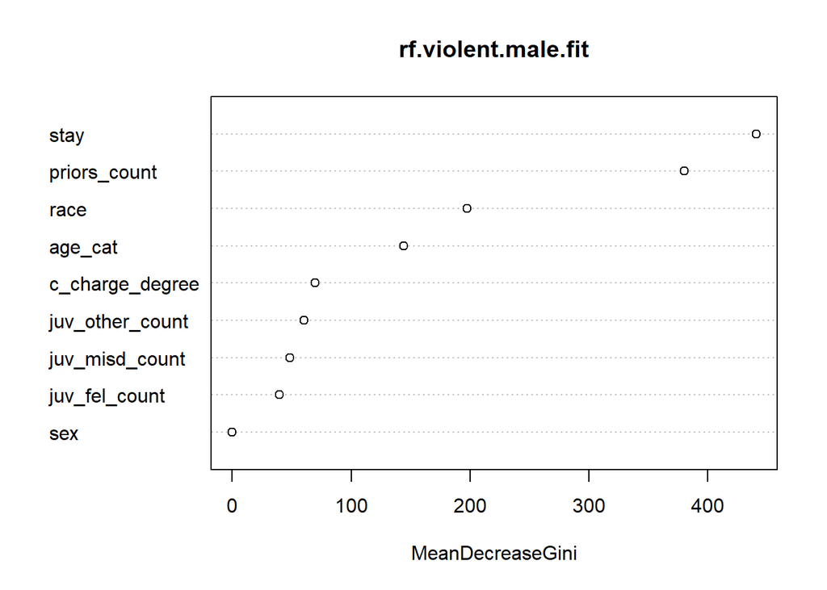

```r
varImpPlot(rf.violent.male.fit)
```

```r
rf.violent.male.predict <- predict(rf.violent.male.fit, newdata = raw.score.violent.df.male.test, type = "prob")
conf.male.v <- confusionMatrix(data = as.factor(ifelse(rf.violent.male.predict[, "1"] > 0.5, 1, 0)),
                reference = as.factor(raw.score.violent.df.male.test$is_violent_recid),
                dnn = c("Prediction", "Reference"))
conf.male.v
```

```
## Confusion Matrix and Statistics
##
##           Reference
## Prediction    0    1
##          0   93    6
##          1  525 2706
##
##                Accuracy : 0.8405
##                  95% CI : (0.8277, 0.8528)
##     No Information Rate : 0.8144
##     P-Value [Acc > NIR] : 4.333e-05
##
##                   Kappa : 0.2194
##
##  Mcnemar's Test P-Value : < 2.2e-16
##
##             Sensitivity : 0.15049
##             Specificity : 0.99779
##          Pos Pred Value : 0.93939
##          Neg Pred Value : 0.83751
##              Prevalence : 0.18559
##          Detection Rate : 0.02793
##    Detection Prevalence : 0.02973
##       Balanced Accuracy : 0.57414
##
##        'Positive' Class : 0
##
```

We have an accuracy rate of 84.05% here, which is closer to the female classification rate, but still higher than we’d like. There is probably a gender bias in our model somewhere.

**4.3 Age**

### Data cleaning

Filter out, by levels of `age_cat`.

```r
#nonviolent

raw.score.df.under25.train <- filter(raw.score.df.train, age_cat == "Less than 25")
raw.score.df.25to45.train <- filter(raw.score.df.train, age_cat == "25 - 45")
raw.score.df.over45.train <- filter(raw.score.df.train, age_cat == "Greater than 45")

raw.score.df.under25.test <- filter(raw.score.df.test, age_cat == "Less than 25")
raw.score.df.25to45.test <- filter(raw.score.df.test, age_cat == "25 - 45")
raw.score.df.over45.test <- filter(raw.score.df.test, age_cat == "Greater than 45")

#violent

raw.score.violent.df.under25.train <- filter(raw.score.violent.df.train, age_cat == "Less than 25")
raw.score.violent.df.25to45.train <- filter(raw.score.violent.df.train, age_cat == "25 - 45")
raw.score.violent.df.over45.train <- filter(raw.score.violent.df.train, age_cat == "Greater than 45")

raw.score.violent.df.under25.test <- filter(raw.score.violent.df.test, age_cat == "Less than 25")
raw.score.violent.df.25to45.test <- filter(raw.score.violent.df.test, age_cat == "25 - 45")
raw.score.violent.df.over45.test <- filter(raw.score.violent.df.test, age_cat == "Greater than 45")
```

### Random Forest for Nonviolent

```r
#random forest
rf.under25.fit <- randomForest(is_recid ~ ., data = raw.score.df.under25.train)
print(rf.under25.fit)
```

```
##
## Call:
##  randomForest(formula = is_recid ~ ., data = raw.score.df.under25.train)
##                Type of random forest: classification
##                      Number of trees: 500
## No. of variables tried at each split: 3
##
##         OOB estimate of  error rate: 12.76%
## Confusion matrix:
##    0    1  class.error
## 0 20  658 0.9705014749
## 1  1 4486 0.0002228661
```

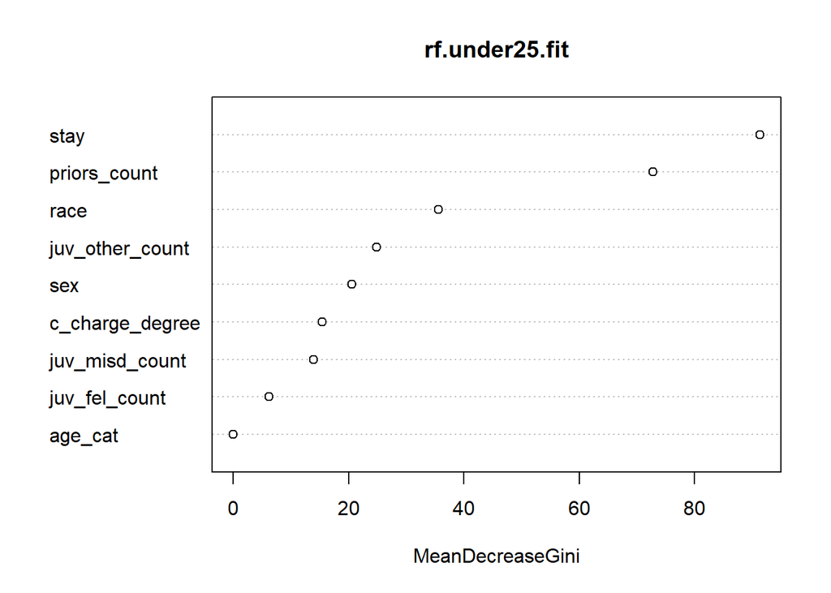

```r
varImpPlot(rf.under25.fit)
```

```r
rf.under25.predict <- predict(rf.under25.fit, newdata = raw.score.df.under25.test, type = "prob")
conf.u25 <- confusionMatrix(data = as.factor(ifelse(rf.under25.predict[, "1"] > 0.5, 1, 0)),
                reference = as.factor(raw.score.df.under25.test$is_recid),
                dnn = c("Prediction", "Reference"))
conf.u25
```

```
## Confusion Matrix and Statistics
##
##           Reference
## Prediction    0    1
##          0    1    0
##          1  150 1069
##
##                Accuracy : 0.877
##                  95% CI : (0.8573, 0.895)
##     No Information Rate : 0.8762
##     P-Value [Acc > NIR] : 0.487
##
##                   Kappa : 0.0115
##
##  Mcnemar's Test P-Value : <2e-16
##
##             Sensitivity : 0.0066225
##             Specificity : 1.0000000
##          Pos Pred Value : 1.0000000
##          Neg Pred Value : 0.8769483
##              Prevalence : 0.1237705
##          Detection Rate : 0.0008197
##    Detection Prevalence : 0.0008197
##       Balanced Accuracy : 0.5033113
##
##        'Positive' Class : 0
##
```

Our model has a 87.7% classification rate for people under 25.

```r
#random forest
rf.25to45.fit <- randomForest(is_recid ~ ., data = raw.score.df.25to45.train)
print(rf.25to45.fit)
```

```
##
## Call:
##  randomForest(formula = is_recid ~ ., data = raw.score.df.25to45.train)
##                Type of random forest: classification
##                      Number of trees: 500
## No. of variables tried at each split: 3
##
##         OOB estimate of  error rate: 17.09%
## Confusion matrix:
##    0    1 class.error
## 0 47 1296 0.965003723
## 1 26 6366 0.004067584
```

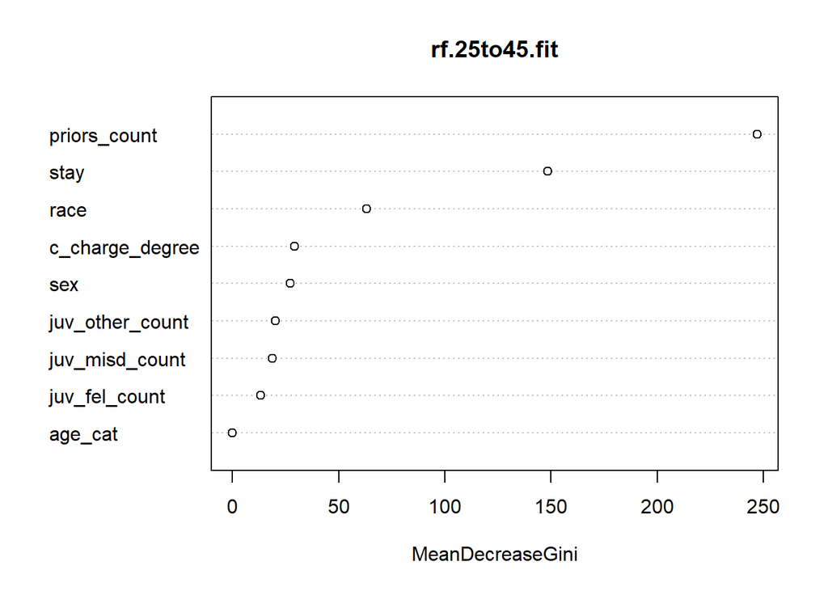

```r
varImpPlot(rf.25to45.fit)
```

```r
rf.25to45.predict <- predict(rf.25to45.fit, newdata = raw.score.df.25to45.test, type = "prob")
conf.2545 <- confusionMatrix(data = as.factor(ifelse(rf.25to45.predict[, "1"] > 0.5, 1, 0)),
                reference = as.factor(raw.score.df.25to45.test$is_recid),
                dnn = c("Prediction", "Reference"))
conf.2545
```

```
## Confusion Matrix and Statistics
##
##           Reference
## Prediction    0    1
##          0   12    7
##          1  295 1620
##
##                Accuracy : 0.8438
##                  95% CI : (0.8269, 0.8598)
##     No Information Rate : 0.8413
##     P-Value [Acc > NIR] : 0.3922
##
##                   Kappa : 0.0562
##
##  Mcnemar's Test P-Value : <2e-16
##
##             Sensitivity : 0.039088
##             Specificity : 0.995698
##          Pos Pred Value : 0.631579
##          Neg Pred Value : 0.845953
##              Prevalence : 0.158738
##          Detection Rate : 0.006205
##    Detection Prevalence : 0.009824
##       Balanced Accuracy : 0.517393
##
##        'Positive' Class : 0
##
```

Here we achieve a slightly less classification rate of about 84.38% for individuals between 25 and 45.

```r
#random forest
rf.over45.fit <- randomForest(is_recid ~ ., data = raw.score.df.over45.train)
print(rf.over45.fit)
```

```
##
## Call:
##  randomForest(formula = is_recid ~ ., data = raw.score.df.over45.train)
##                Type of random forest: classification
##                      Number of trees: 500
## No. of variables tried at each split: 3
##
##         OOB estimate of  error rate: 19.46%
## Confusion matrix:
##    0    1 class.error
## 0 87  901  0.91194332
## 1 47 3836  0.01210404
```

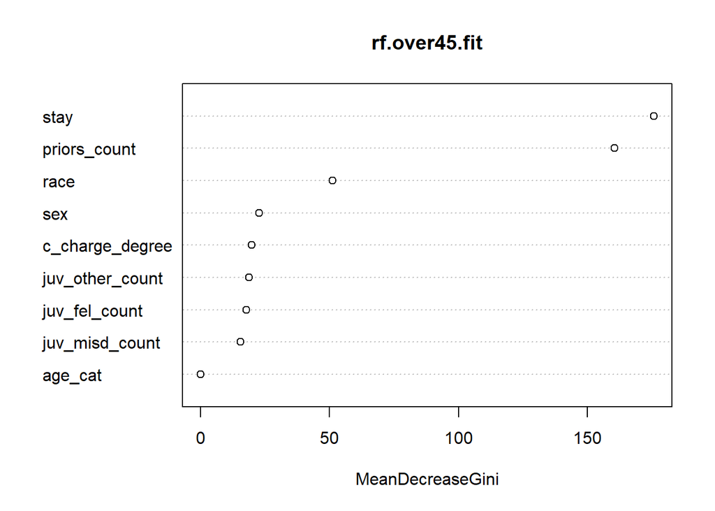

```r
varImpPlot(rf.over45.fit)
```

```r
rf.over45.predict <- predict(rf.over45.fit, newdata = raw.score.df.over45.test, type = "prob")
conf.o45 <- confusionMatrix(data = as.factor(ifelse(rf.over45.predict[, "1"] > 0.5, 1, 0)),
                reference = as.factor(raw.score.df.over45.test$is_recid),
                dnn = c("Prediction", "Reference"))
conf.o45
```

```
## Confusion Matrix and Statistics
##
##           Reference
## Prediction    0    1
##          0   27    5
##          1  249 1008
##
##                Accuracy : 0.8029
##                  95% CI : (0.7802, 0.8243)
##     No Information Rate : 0.7859
##     P-Value [Acc > NIR] : 0.07111
##
##                   Kappa : 0.1369
##
##  Mcnemar's Test P-Value : < 2e-16
##
##             Sensitivity : 0.09783
##             Specificity : 0.99506
##          Pos Pred Value : 0.84375
##          Neg Pred Value : 0.80191
##              Prevalence : 0.21412
##          Detection Rate : 0.02095
##    Detection Prevalence : 0.02483
##       Balanced Accuracy : 0.54645
##
##        'Positive' Class : 0
##
```

We acheive a classification rate of about 80.29%, which is a substantial drop from the 87.7% we had with under 25 year olds. This again implies some sort of bias in our model.

### Random Forest for Violent

```r
#violent
rf.violent.under25.fit <- randomForest(is_violent_recid ~ ., data = raw.score.violent.df.under25.train)
print(rf.violent.under25.fit)
```

```
##
## Call:
##  randomForest(formula = is_violent_recid ~ ., data = raw.score.violent.df.under25.train)
##                Type of random forest: classification
##                      Number of trees: 500
## No. of variables tried at each split: 3
##
##         OOB estimate of  error rate: 12.05%
## Confusion matrix:
##     0    1 class.error
## 0 144  561   0.7957447
## 1   0 3949   0.0000000
```

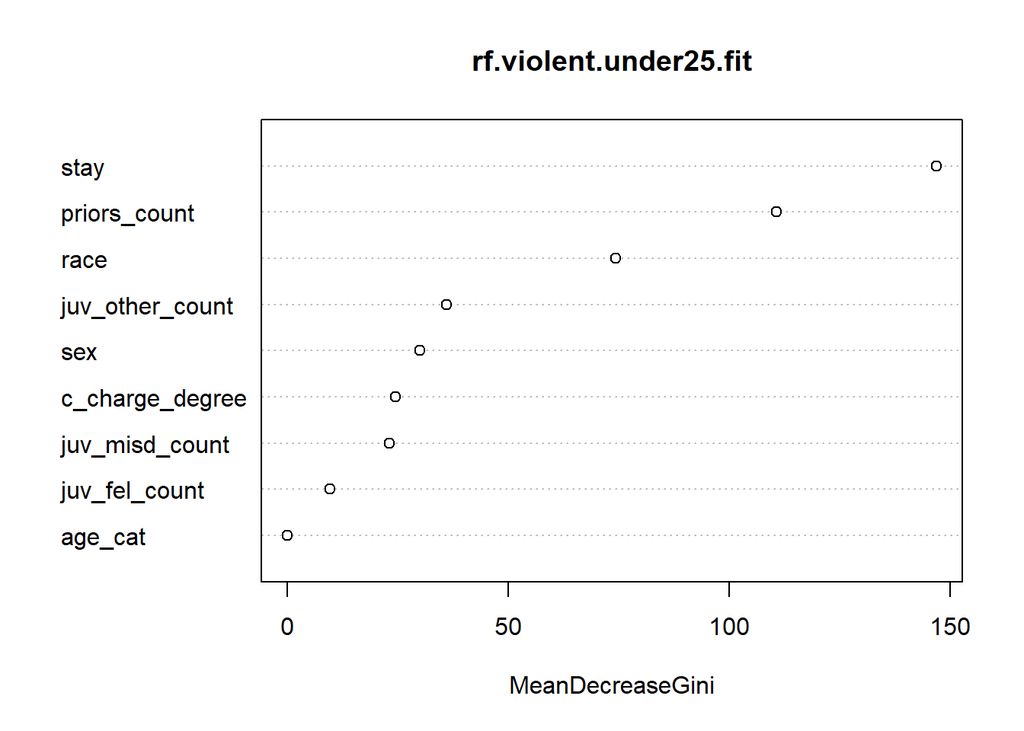

```r
varImpPlot(rf.violent.under25.fit)
```

```r
rf.violent.under25.predict <- predict(rf.violent.under25.fit, newdata = raw.score.violent.df.under25.test, type = "prob")
conf.u25.v <- confusionMatrix(data = as.factor(ifelse(rf.violent.under25.predict[, "1"] > 0.5, 1, 0)),
                reference = as.factor(raw.score.violent.df.under25.test$is_violent_recid),
                dnn = c("Prediction", "Reference"))
conf.u25.v
```

```
## Confusion Matrix and Statistics
##
##           Reference
## Prediction    0    1
##          0   33    0
##          1  145 1040
##
##                Accuracy : 0.881
##                  95% CI : (0.8614, 0.8986)
##     No Information Rate : 0.8539
##     P-Value [Acc > NIR] : 0.00348
##
##                   Kappa : 0.2799
##
##  Mcnemar's Test P-Value : < 2e-16
##
##             Sensitivity : 0.18539
##             Specificity : 1.00000
##          Pos Pred Value : 1.00000
##          Neg Pred Value : 0.87764
##              Prevalence : 0.14614
##          Detection Rate : 0.02709
##    Detection Prevalence : 0.02709
##       Balanced Accuracy : 0.59270
##
##        'Positive' Class : 0
##
```

Here we have a classification rate of 88.1%.

```r
#violent
rf.violent.male.fit <- randomForest(is_violent_recid ~ ., data = raw.score.violent.df.male.train)
print(rf.violent.male.fit)
```

```
##
## Call:
##  randomForest(formula = is_violent_recid ~ ., data = raw.score.violent.df.male.train)
##                Type of random forest: classification
##                      Number of trees: 500
## No. of variables tried at each split: 3
##
##         OOB estimate of  error rate: 15.48%
## Confusion matrix:
##     0     1  class.error
## 0 342  2072 0.8583264292
## 1   8 11014 0.0007258211
```

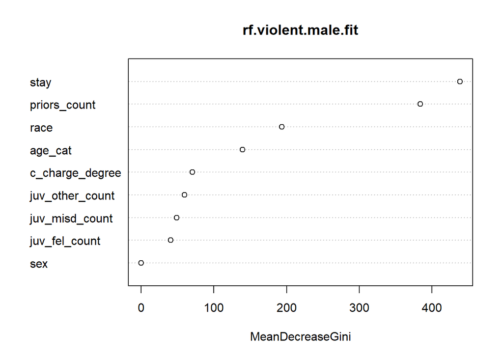

```r
varImpPlot(rf.violent.male.fit)
```

```r
rf.violent.male.predict <- predict(rf.violent.male.fit, newdata = raw.score.violent.df.male.test, type = "prob")
conf.2545.v <- confusionMatrix(data = as.factor(ifelse(rf.violent.male.predict[, "1"] > 0.5, 1, 0)),
                reference = as.factor(raw.score.violent.df.male.test$is_violent_recid),
                dnn = c("Prediction", "Reference"))
conf.2545.v
```

```
## Confusion Matrix and Statistics
##
##           Reference
## Prediction    0    1
##          0   79    0
##          1  539 2712
##
##                Accuracy : 0.8381
##                  95% CI : (0.8252, 0.8505)
##     No Information Rate : 0.8144
##     P-Value [Acc > NIR] : 0.0001889
##
##                   Kappa : 0.1927
##
##  Mcnemar's Test P-Value : < 2.2e-16
##
##             Sensitivity : 0.12783
##             Specificity : 1.00000
##          Pos Pred Value : 1.00000
##          Neg Pred Value : 0.83420
##              Prevalence : 0.18559
##          Detection Rate : 0.02372
##    Detection Prevalence : 0.02372
##       Balanced Accuracy : 0.56392
##
##        'Positive' Class : 0
##
```

Here we are at a classification rate of 83.81%.

```r
#violent
rf.violent.male.fit <- randomForest(is_violent_recid ~ ., data = raw.score.violent.df.male.train)
print(rf.violent.male.fit)
```

```
##
## Call:
##  randomForest(formula = is_violent_recid ~ ., data = raw.score.violent.df.male.train)
##                Type of random forest: classification
##                      Number of trees: 500
## No. of variables tried at each split: 3
##
##         OOB estimate of  error rate: 15.24%
## Confusion matrix:
##     0     1 class.error
## 0 384  2030 0.840927920
## 1  18 11004 0.001633097
```

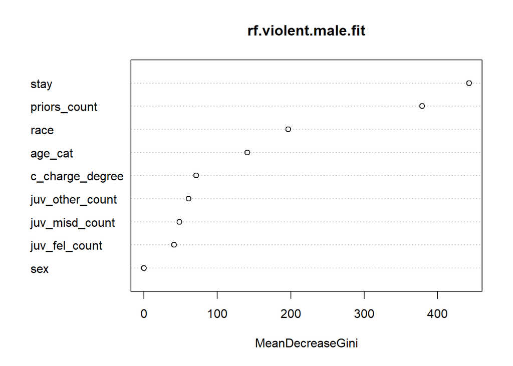

```r
varImpPlot(rf.violent.male.fit)
```

```r
rf.violent.male.predict <- predict(rf.violent.male.fit, newdata = raw.score.violent.df.male.test, type = "prob")
conf.o45.v <- confusionMatrix(data = as.factor(ifelse(rf.violent.male.predict[, "1"] > 0.5, 1, 0)),
                reference = as.factor(raw.score.violent.df.male.test$is_violent_recid),
                dnn = c("Prediction", "Reference"))
conf.o45.v
```

```
## Confusion Matrix and Statistics
##
##           Reference
## Prediction    0    1
##          0   90    6
##          1  528 2706
##
##                Accuracy : 0.8396
##                  95% CI : (0.8267, 0.852)
##     No Information Rate : 0.8144
##     P-Value [Acc > NIR] : 7.647e-05
##
##                   Kappa : 0.2128
##
##  Mcnemar's Test P-Value : < 2.2e-16
##
##             Sensitivity : 0.14563
##             Specificity : 0.99779
##          Pos Pred Value : 0.93750
##          Neg Pred Value : 0.83673
##              Prevalence : 0.18559
##          Detection Rate : 0.02703
##    Detection Prevalence : 0.02883
##       Balanced Accuracy : 0.57171
##
##        'Positive' Class : 0
##
```

Here again we have a classification rate of 83.96%. Here again as in gender, we see that the gap between classification rates isn’t as high for violent crimes as it was for nonviolent, but there’s still reason to be skeptical of our model due to bias here.

As we have seen from these analyses, our models from both parts (1) and (2) are unequally predictive across racial, sex, and age categories. This hinders our model’s capability of classifiying new data due to this bias.

**5. Comparing our RAIs to COMPAS**

We then compared our RAIs we built againist COMPAS to see if the classification rate improved.

**COMPAS RAI**

##### Non-violent COMPAS Recidivism Prediction

```r
performance <- compas.score.two.year %>%
  filter(score_text != "Medium")

performance$score_text <- factor(performance$score_text, levels = c("Low", "High"))

tab.comp = table(performance$score_text, performance$is_recid)
tab.comp
```

```
##
##           0    1
##   Low  2566 1331
##   High  362 1041
```

```r
sum(diag(tab.comp))/sum(tab.comp)
```

```
## [1] 0.680566
```

The accuracy of COMPAS score for non-violent recidivism is about 68.06%. This is lower than the accuracy of our model, which has an accuracy of about 84.15%

We removed medium from our analysis since medium is a vague term, and felt it would’ve been difficult to classify. We assumed that Low corresponds to 0 and High corresponds to 1.

##### Violent COMPAS Recidivism Prediction

```r
performance_violent <- compas.score.two.year %>%
  filter(v_score_text != "Medium")

performance_violent$v_score_text <- factor(performance_violent$v_score_text, levels = c("Low", "High"))

tab.comp.violent = table(performance_violent$v_score_text, performance_violent$is_violent_recid)
tab.comp.violent
```

```
##
##           0    1
##   Low  4379  382
##   High  540  174
```

```r
sum(diag(tab.comp.violent))/sum(tab.comp.violent)
```

```
## [1] 0.8315982
```

The accuracy of COMPAS score for violent recidivism is about 83.16%. This is just a little lower than of our model, which has an accuracy of about 84%

Overall, our model does a better job of prediciting non-violent recidivism than the COMPAS score and does about the same predicting violent recidivism.

##### Bias in COMPAS

```r
performance <- subset.score.df[,-c(2,3,6,7,9,10,14,15,17,20)]
performance$score_text <- factor(performance$score_text, levels = c("Low", "Medium", "High"))


performance.logit <- glm(score_text ~ ., family = "binomial", data = performance)
summary(performance.logit)
```

```
##
## Call:
## glm(formula = score_text ~ ., family = "binomial", data = performance)
##
## Deviance Residuals:
##     Min       1Q   Median       3Q      Max
## -4.1735  -0.8210  -0.4824   0.9214   2.3116
##
## Coefficients:
##                          Estimate Std. Error z value Pr(>|z|)
## (Intercept)            -0.0613668  0.0727667  -0.843  0.39904
## sexFemale               0.2356379  0.0699089   3.371  0.00075 ***
## age_cat25 - 45         -1.2280362  0.0702116 -17.490  < 2e-16 ***
## age_catGreater than 45 -1.5486336  0.0790132 -19.600  < 2e-16 ***
## raceAsian              -0.8554637  0.4413704  -1.938  0.05260 .
## raceCaucasian          -0.5851600  0.0620063  -9.437  < 2e-16 ***
## raceHispanic           -0.8089152  0.1057202  -7.651 1.99e-14 ***
## raceNative American     0.5049407  0.5815780   0.868  0.38527
## raceOther              -1.3166286  0.1465698  -8.983  < 2e-16 ***
## juv_fel_count           0.8320199  0.1600188   5.200 2.00e-07 ***
## juv_misd_count          0.7720178  0.1374047   5.619 1.93e-08 ***
## juv_other_count         0.4354895  0.0836757   5.204 1.95e-07 ***
## priors_count            0.2312764  0.0094719  24.417  < 2e-16 ***
## c_charge_degreeF        0.3691530  0.0599642   6.156 7.45e-10 ***
## stay                    0.0058461  0.0007542   7.752 9.07e-15 ***
## ---
## Signif. codes:  0 '***' 0.001 '**' 0.01 '*' 0.05 '.' 0.1 ' ' 1
##
## (Dispersion parameter for binomial family taken to be 1)
##
##     Null deviance: 9954.0  on 7213  degrees of freedom
## Residual deviance: 7593.2  on 7199  degrees of freedom
## AIC: 7623.2
##
## Number of Fisher Scoring iterations: 6
```

White defendants are 58.5% less likely to receive a higher score correcting for the seriousness of their crime, previous arrests, and future criminal behavior in comparisions to African Americans.

Defendants who are under the age of 25 category are more likely to receive a higher score than the other two categories. Holding everything else constant, those who are age 25-45 are 122.8% less likely to receiving a higher score than those under 25 years old. Additionally, those older than 45 are 154.8% less likely to receiving a higher score.

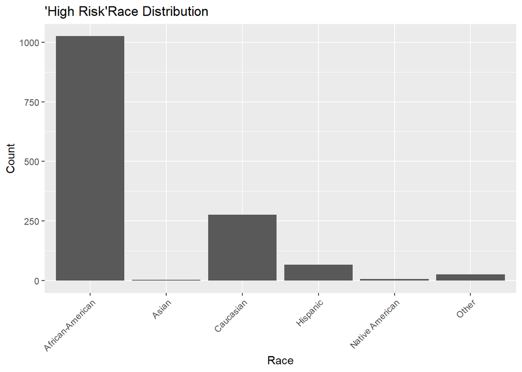

```r
high.risk <- subset(compas.score.two.year, subset = score_text == "High")
low.risk <- subset(compas.score.two.year, subset = score_text == "Low")

#graph
ggplot(high.risk, aes(x = race)) + geom_histogram(stat = "count") + labs(title = "'High Risk'Race Distribution", x = "Race", y = "Count") +  theme(axis.text.x = element_text(angle = 45, vjust = 1, hjust = 1))
```

One of the primary observations with COMPAS model is the sysmatic bias towards labelling African American as “high risk” in comparsion to other races. As mentioned above, white defendants are 58.5% less likely to be labelled as such. In addition, Hispanics are 80.89% less likely to be labelled as “High Risk” as well. Asians and Native Americans are not mentioned in this analysis due to the fact that they make up a small portion of the sample and the quality of results is uncertain.

##### Bias in COMPAS for Violent Recidivism

```r
performance.violent <- violent.subset.score.df[,-c(2,3,6,7,9,10,14,15,18,20)]
performance.violent$score_text <- factor(performance.violent$score_text, levels = c("Low", "Medium", "High"))


performance.violent.logit <- glm(score_text ~ ., family = "binomial", data = performance.violent)
summary(performance.violent.logit)
```

```
##
## Call:
## glm(formula = score_text ~ ., family = "binomial", data = performance.violent)
##
## Deviance Residuals:
##     Min       1Q   Median       3Q      Max
## -2.6401  -0.7642  -0.3793   0.7816   2.9282
##
## Coefficients:
##                         Estimate Std. Error z value Pr(>|z|)
## (Intercept)             1.694907   0.232392   7.293 3.02e-13 ***
## sexMale                -0.195311   0.098299  -1.987 0.046933 *
## age_cat25 - 45         -0.464962   0.131363  -3.540 0.000401 ***
## age_catGreater than 45 -0.100263   0.317851  -0.315 0.752427
## raceAsian              -1.255494   0.659298  -1.904 0.056873 .
## raceCaucasian          -0.555069   0.090142  -6.158 7.38e-10 ***
## raceHispanic           -0.946286   0.154894  -6.109 1.00e-09 ***
## raceNative American     0.268371   0.852956   0.315 0.753038
## raceOther              -1.087134   0.193543  -5.617 1.94e-08 ***
## juv_fel_count           0.540677   0.281270   1.922 0.054572 .
## juv_misd_count          0.568992   0.218699   2.602 0.009276 **
## juv_other_count         0.168600   0.106489   1.583 0.113362
## priors_count            0.298973   0.016174  18.485  < 2e-16 ***
## c_charge_degreeF        0.234843   0.082921   2.832 0.004624 **
## is_recid                0.516251   0.100560   5.134 2.84e-07 ***
## age_offense            -0.079887   0.009473  -8.434  < 2e-16 ***
## ---
## Signif. codes:  0 '***' 0.001 '**' 0.01 '*' 0.05 '.' 0.1 ' ' 1
##
## (Dispersion parameter for binomial family taken to be 1)
##
##     Null deviance: 5194.4  on 3966  degrees of freedom
## Residual deviance: 3733.0  on 3951  degrees of freedom
##   (776 observations deleted due to missingness)
## AIC: 3765
##
## Number of Fisher Scoring iterations: 6
```

White defendants are 55.5% less likely to receive a higher score correcting for the seriousness of their crime, previous arrests, and future criminal behavior in comparisions to African Americans.

Male defendants are 19.5% less likely to receive a higher score in comparisions to their female counterparts, holding all other variables constant.

**Our RAI**

##### Bias for Nonviolent Recidivism

For the sake of interpretability, we used logistic regression to calculate the bias, which had close to the same accuracy rates as our random forest. We are using the same dataframe to maintain consistent observations across comparisons. In this model, we are using recidivism as a proxy for the score_text variable that the COMPAS model is using.

```r
our.performance <- subset.score.df[,-c(2,3,6,7,9,10,14,15,18,20)]
our.performance.logit <- glm(is_recid ~ ., family = "binomial", data = our.performance)

summary(our.performance.logit)
```

```
##
## Call:
## glm(formula = is_recid ~ ., family = "binomial", data = our.performance)
##
## Deviance Residuals:
##     Min       1Q   Median       3Q      Max
## -3.6119  -1.0103  -0.7151   1.1214   1.9038
##
## Coefficients:
##                          Estimate Std. Error z value Pr(>|z|)
## (Intercept)            -0.0911253  0.0674712  -1.351 0.176830
## sexFemale              -0.3017596  0.0647255  -4.662 3.13e-06 ***
## age_cat25 - 45         -0.5187736  0.0640316  -8.102 5.41e-16 ***
## age_catGreater than 45 -0.9004492  0.0711382 -12.658  < 2e-16 ***
## raceAsian              -0.4513218  0.3837035  -1.176 0.239505
## raceCaucasian          -0.1911907  0.0569252  -3.359 0.000783 ***
## raceHispanic           -0.3441323  0.0933139  -3.688 0.000226 ***
## raceNative American     0.2323254  0.5324202   0.436 0.662578
## raceOther              -0.3219836  0.1169306  -2.754 0.005894 **
## juv_fel_count           0.3324058  0.0964183   3.448 0.000566 ***
## juv_misd_count          0.1593466  0.0811140   1.964 0.049475 *
## juv_other_count         0.2754588  0.0682977   4.033 5.50e-05 ***
## priors_count            0.1339478  0.0073504  18.223  < 2e-16 ***
## c_charge_degreeF        0.2038102  0.0538249   3.787 0.000153 ***
## stay                    0.0035353  0.0006176   5.724 1.04e-08 ***
## ---
## Signif. codes:  0 '***' 0.001 '**' 0.01 '*' 0.05 '.' 0.1 ' ' 1
##
## (Dispersion parameter for binomial family taken to be 1)
##
##     Null deviance: 9990.5  on 7213  degrees of freedom
## Residual deviance: 8984.1  on 7199  degrees of freedom
## AIC: 9014.1
##
## Number of Fisher Scoring iterations: 4
```

White defendants are 19% less likely to receive a higher score correcting for the seriousness of their crime, previous arrests, and future criminal behavior in comparisions to African Americans. This is a very smaller likelihood in comparison to COMPAS model.

Defendants who are under the age of 25 category are more likely to receive a higher score than the other two categories. Holding everything else constant, those who are age 25-45 are 51.8% less likely to receiving a higher score than those under 25 years old. Additionally, those older than 45 are 90% less likely to receiving a higher score. This is less in comparison to COMPAS score.

##### Bias for Violent Recidivism

Even though our random forest model ended up being the best model, we chose to explore this analysis with a logistic regression for interpretibility’s sake and to keep things the same across the nonviolent and violent analysis.

```r
our.performance.violent <- violent.subset.score.df[,-c(2,3,6,7,9,10,14,15,17,20)]
our.performance.violent.logit <- glm(is_violent_recid ~ ., family = "binomial", data = our.performance.violent)

summary(our.performance.violent.logit)
```

```
##
## Call:
## glm(formula = is_violent_recid ~ ., family = "binomial", data = our.performance.violent)
##
## Deviance Residuals:
##     Min       1Q   Median       3Q      Max
## -2.1719  -0.5786  -0.4502  -0.3240   2.5951
##
## Coefficients:
##                         Estimate Std. Error z value Pr(>|z|)
## (Intercept)              0.13000    0.26936   0.483   0.6294
## sexMale                  0.51381    0.12612   4.074 4.62e-05 ***
## age_cat25 - 45           0.23178    0.14753   1.571   0.1162
## age_catGreater than 45   0.71102    0.35252   2.017   0.0437 *
## raceAsian               -0.71320    0.77588  -0.919   0.3580
## raceCaucasian           -0.11935    0.10644  -1.121   0.2621
## raceHispanic            -0.30564    0.17816  -1.716   0.0863 .
## raceNative American      0.37624    0.77642   0.485   0.6280
## raceOther               -0.01676    0.20694  -0.081   0.9354
## juv_fel_count            0.10994    0.12540   0.877   0.3807
## juv_misd_count           0.15567    0.10462   1.488   0.1367
## juv_other_count          0.08742    0.08361   1.046   0.2958
## priors_count             0.08412    0.01210   6.954 3.56e-12 ***
## c_charge_degreeF        -0.19562    0.09393  -2.083   0.0373 *
## score_textLow           -1.27651    0.13394  -9.530  < 2e-16 ***
## score_textMedium        -0.74050    0.12614  -5.871 4.34e-09 ***
## score_textN/A          -11.89239  237.05671  -0.050   0.9600
## age_offense             -0.04965    0.01049  -4.734 2.20e-06 ***
## ---
## Signif. codes:  0 '***' 0.001 '**' 0.01 '*' 0.05 '.' 0.1 ' ' 1
##
## (Dispersion parameter for binomial family taken to be 1)
##
##     Null deviance: 3624.0  on 3971  degrees of freedom
## Residual deviance: 3159.2  on 3954  degrees of freedom
##   (771 observations deleted due to missingness)
## AIC: 3195.2
##
## Number of Fisher Scoring iterations: 12
```

White defendants are 11.9% less likely to receive a higher score correcting for the seriousness of their crime, previous arrests, and future criminal behavior in comparisions to African Americans. This is still smaller than the COMPAS model.

Male defendants are 51.4% more likely to receive a higher score in comparisions to their male counterparts, holding all other variables constant. This is vastly different than COMPAS, and indicates that our model penalizes being a male. However, this difference may be attributed to the fact that we used a logistic regression model for this analysis, which is not the optimal model for this scenario.

**6. Conclusion**

In order to best predict two-year non-violent and violent recidivism, we found that the random forest models were the best models for prediction. These models were able to yield an accuracy of 84.15% and 84.1%, respectively. The most important predictors for recidivism and violent recidivism both seem to be `stay`, and `priors_count`, with `race` and `age_cat` as our second tier important variables.

While we were able to predict non-violent and violent recidivisim with a relatively high accuracy, we found that our model was biased. Our models did not predict equally across racial, age, and gender categories, which could have some negative implications if using these models to predict recidivism in future cases.

We also found that our model for predicting non-violent recidivism had a higher accuracy than the COMPAS model did. However, our model for prediciting violent recidivism did similarly to the COMPAS model. We did see some slight differences between our classifications and the COMPAS model. The COMPAS model seems to favor giving higher scores for those who are African American under the age of 25. This was the same for our models as well but to a lesser extent. While this is less than what we have seen in the COMPAS model, our model still seems to have a preference to classify as likely to recidivized to male African Africans under the age of 25.